# Respiratory diseases

# 1 Description of DataSchema variable

The description of harmonised variable is the following:

- Short name: `h_respiratory`
- Variable label: `Chronic respiratory diseases such respiratory, CPD, COPD, bronchitis, emphysema`
- Variable description: `The participant has one or more of the following respiratory diseases: respiratory, chronic bronchitis, emphysema, chronic pulmonary disease, chronic obstructive pulmonary disease`
- Domain: `Diseases`
- Value type: `categorical`
- Category coding:

| **Code** | **Category Label** |
| --- | --- |
| 0 | no respiratory disease |
| 1 | yes, respiratory disease |

- Category missings:

| **Code** | **Category Label** |
| --- | --- |
| 991 | CAPI/interviewer error |
| 992 | Impute |
| 993 | Disable to measure |
| 994 | Not attempt/not done |
| 995 | Does not answer |
| 996 | Not applicable |
| 997 | Refuse |
| 998 | Do not know |
| 999 | Missing |

# 2 Data process

## 2.1 England

### 2.1.1 Wave 1

#### 2.1.1.1 Study-specific variable description

| **Name** | `h_asthma` | `h_cpd` |
| --- | --- | --- |
| **Label** | `History of Asthma` | `History of chronic pulmonary disorders` |
| **Table name** | `h_asthma` | `h_cpd` |
| **Categories** | `1 = Asthma` `0 = No asthma` | `1 = chronic pulmonary disease` `0 = NO chronic pulmonary disease` |
| **Missings** | `997 = Refuse` `998 = Do not know` | `997 = Refuse` `998 = Do not know` |
| **Description** |  |  |

h_asthma

| Sample size | Missing values |
| --- | --- |
| 12099 | 10 |

Category

|  | 0 | 1 |
| --- | --- | --- |
| Frequency | 10672.00 | 1417.00 |
| Percentage | 88.21 | 11.71 |

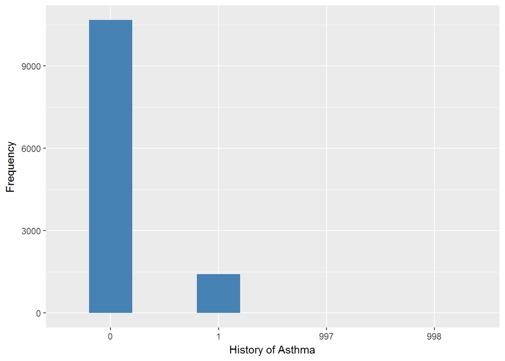

h_cpd

| Sample size | Missing values |
| --- | --- |
| 12099 | 10 |

Category

|  | 0 | 1 |
| --- | --- | --- |
| Frequency | 11326.00 | 763.00 |
| Percentage | 93.61 | 6.31 |

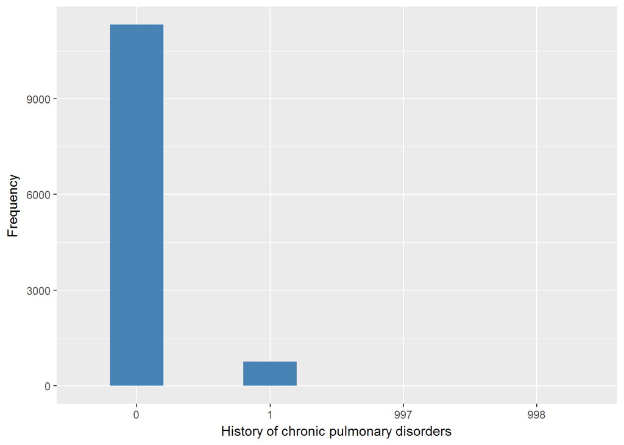

#### 2.1.1.2 Harmonisation algorithm

To compute `h_respiratory` from the study-specific variable it has to be recoded as follows:

- `h_asthma == 0 and h_cpd == 0 into 0`
- `h_asthma == 1 or h_cpd == 1 into 1`
- `keep missing values into themselves`

**R script:**

```r
# Categorical variable harmonization
ELSA_ds_w1 <- tibble(id = ELSA_w1$id)
ELSA_ds_w1$h_respiratory <- rep(999, length(ELSA_w1$id))

ELSA_ds_w1$h_respiratory[which(ELSA_w1$h_asthma == 0 & ELSA_w1$h_cpd == 0)] <- 0
ELSA_ds_w1$h_respiratory[which(ELSA_w1$h_asthma == 1 | ELSA_w1$h_cpd == 1)] <- 1
ELSA_ds_w1$h_respiratory[which((ELSA_w1$h_asthma == 997 & (ELSA_w1$h_cpd !=
    1 | is.na(ELSA_w1$h_cpd))) | (ELSA_w1$h_cpd == 997 & (ELSA_w1$h_asthma !=
    1 | is.na(ELSA_w1$h_asthma))))] <- 997
ELSA_ds_w1$h_respiratory[which((ELSA_w1$h_asthma == 998 & (ELSA_w1$h_cpd !=
    1 | is.na(ELSA_w1$h_cpd))) | (ELSA_w1$h_cpd == 998 & (ELSA_w1$h_asthma !=
    1 | is.na(ELSA_w1$h_asthma))))] <- 998
```

#### 2.1.1.3 Statistics of the new harmonized variable

Chronic respiratory diseases such respiratory, CPD, COPD, bronchitis, emphysema

| Sample size | Missing values |
| --- | --- |
| 12099 | 10 |

Category

|  | 0 | 1 |
| --- | --- | --- |
| Frequency | 10154.00 | 1935.00 |
| Percentage | 83.92 | 15.99 |

Type of missing

|  | 991 | 992 | 993 | 994 | 995 | 996 | 997 | 998 | 999 | NA |
| --- | --- | --- | --- | --- | --- | --- | --- | --- | --- | --- |
| Frequency | 0 | 0 | 0 | 0 | 0 | 0 | 4.00 | 6.00 | 0 | 0 |
| Percentage | 0 | 0 | 0 | 0 | 0 | 0 | 0.03 | 0.05 | 0 | 0 |

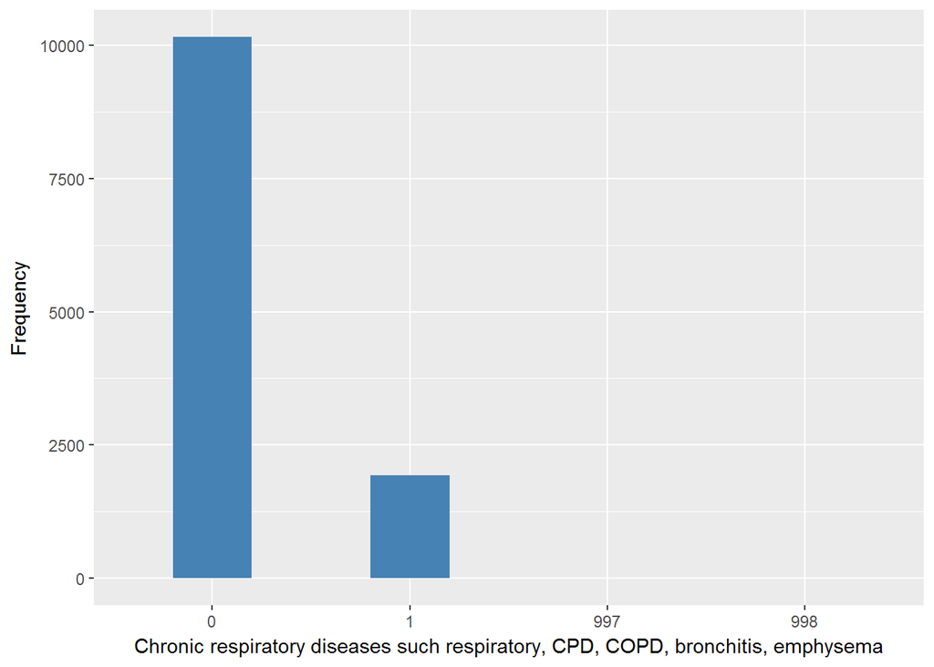

#### 2.1.1.4 Validation

|  | all 0->0 | some 1->1 | 997->997 | 998->998 |
| --- | --- | --- | --- | --- |
| BeforeH | 10154 | 1935 | 4 | 6 |
| AfterH | 10154 | 1935 | 4 | 6 |

### 2.1.2 Wave 2

#### 2.1.2.1 Study-specific variable description

| **Name** | `h_asthma` | `h_cpd` |
| --- | --- | --- |
| **Label** | `History of Asthma` | `History of chronic pulmonary disorders` |
| **Table name** | `h_asthma` | `h_cpd` |
| **Categories** | `1 = Asthma` `0 = No asthma` | `1 = chronic pulmonary disease` `0 = NO chronic pulmonary disease` |
| **Missings** | `997 = Refuse` `998 = Do not know` | `997 = Refuse` `998 = Do not know` |
| **Description** |  |  |

h_asthma

| Sample size | Missing values |
| --- | --- |
| 9432 | 5 |

Category

|  | 0 | 1 |
| --- | --- | --- |
| Frequency | 8215.0 | 1212.00 |
| Percentage | 87.1 | 12.85 |

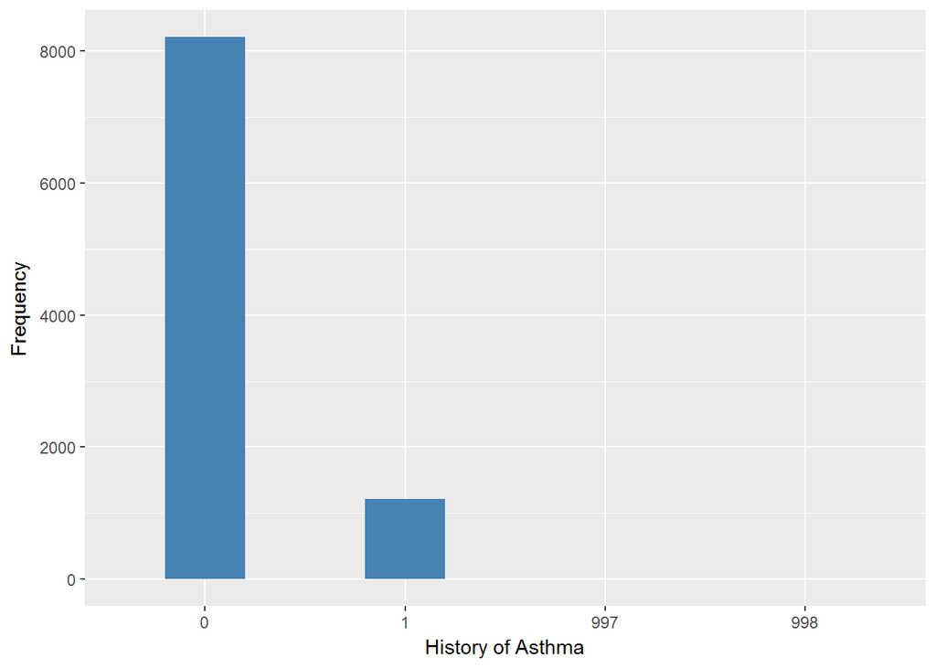

h_cpd

| Sample size | Missing values |
| --- | --- |
| 9432 | 5 |

Category

|  | 0 | 1 |
| --- | --- | --- |
| Frequency | 8738.00 | 689.0 |
| Percentage | 92.64 | 7.3 |

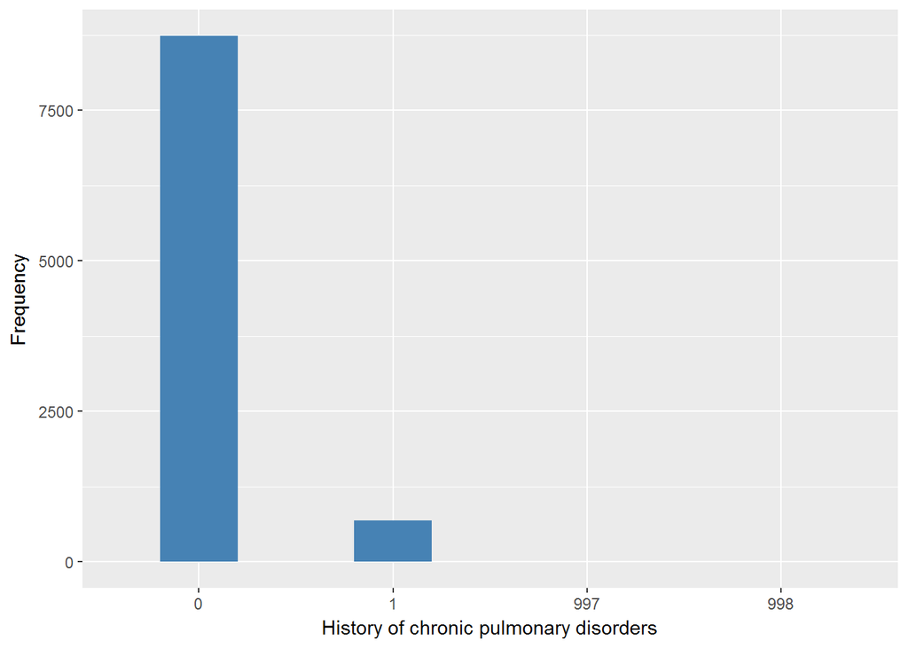

#### 2.1.2.2 Harmonisation algorithm

To compute `h_respiratory` from the study-specific variable it has to be recoded as follows:

- `h_asthma == 0 and h_cpd == 0 into 0`
- `h_asthma == 1 or h_cpd == 1 into 1`
- `keep missing values into themselves`

**R script:**

```r
# Categorical variable harmonization
ELSA_ds_w2 <- tibble(id = ELSA_w2$id)

ELSA_ds_w2$h_respiratory <- rep(999, length(ELSA_ds_w2$id))
ELSA_ds_w2$h_respiratory[which(ELSA_w2$h_asthma == 0 & ELSA_w2$h_cpd == 0)] <- 0
ELSA_ds_w2$h_respiratory[which(ELSA_w2$h_asthma == 1 | ELSA_w2$h_cpd == 1)] <- 1
ELSA_ds_w2$h_respiratory[which((ELSA_w2$h_asthma == 997 & ELSA_w2$h_cpd != 1) |
    (ELSA_w2$h_cpd == 997 & ELSA_w2$h_asthma != 1))] <- 997
ELSA_ds_w2$h_respiratory[which((ELSA_w2$h_asthma == 998 & ELSA_w2$h_cpd != 1) |
    (ELSA_w2$h_cpd == 998 & ELSA_w2$h_asthma != 1))] <- 998
```

#### 2.1.2.3 Statistics of the new harmonized variable

Chronic respiratory diseases such respiratory, CPD, COPD, bronchitis, emphysema

| Sample size | Missing values |
| --- | --- |
| 9432 | 4 |

Category

|  | 0 | 1 |
| --- | --- | --- |
| Frequency | 7764.00 | 1664.00 |
| Percentage | 82.32 | 17.64 |

Type of missing

|  | 991 | 992 | 993 | 994 | 995 | 996 | 997 | 998 | 999 | NA |
| --- | --- | --- | --- | --- | --- | --- | --- | --- | --- | --- |
| Frequency | 0 | 0 | 0 | 0 | 0 | 0 | 1.00 | 3.00 | 0 | 0 |
| Percentage | 0 | 0 | 0 | 0 | 0 | 0 | 0.01 | 0.03 | 0 | 0 |

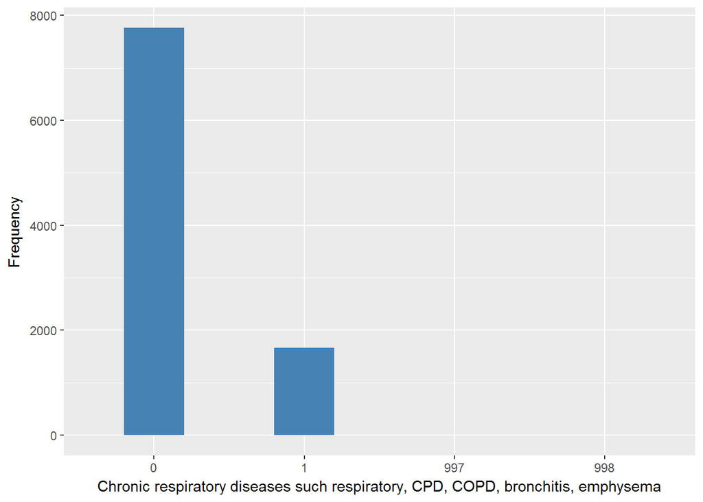

#### 2.1.2.4 Validation

|  | all 0->0 | some 1->1 | 997->997 | 998->998 |
| --- | --- | --- | --- | --- |
| BeforeH | 7764 | 1664 | 1 | 3 |
| AfterH | 7764 | 1664 | 1 | 3 |

### 2.1.3 Wave 3

#### 2.1.3.1 Study-specific variable description

| **Name** | `h_asthma` | `h_cpd` |
| --- | --- | --- |
| **Label** | `History of Asthma` | `History of chronic pulmonary disorders` |
| **Table name** | `h_asthma` | `h_cpd` |
| **Categories** | `1 = Asthma` `0 = No asthma` | `1 = chronic pulmonary disease` `0 = NO chronic pulmonary disease` |
| **Missings** | `996 = Not applicable` | `996 = Not applicable` |
| **Description** |  |  |

h_asthma

| Sample size | Missing values |
| --- | --- |
| 9771 | 8 |

Category

|  | 0 | 1 |
| --- | --- | --- |
| Frequency | 8454.00 | 1309.0 |
| Percentage | 86.52 | 13.4 |

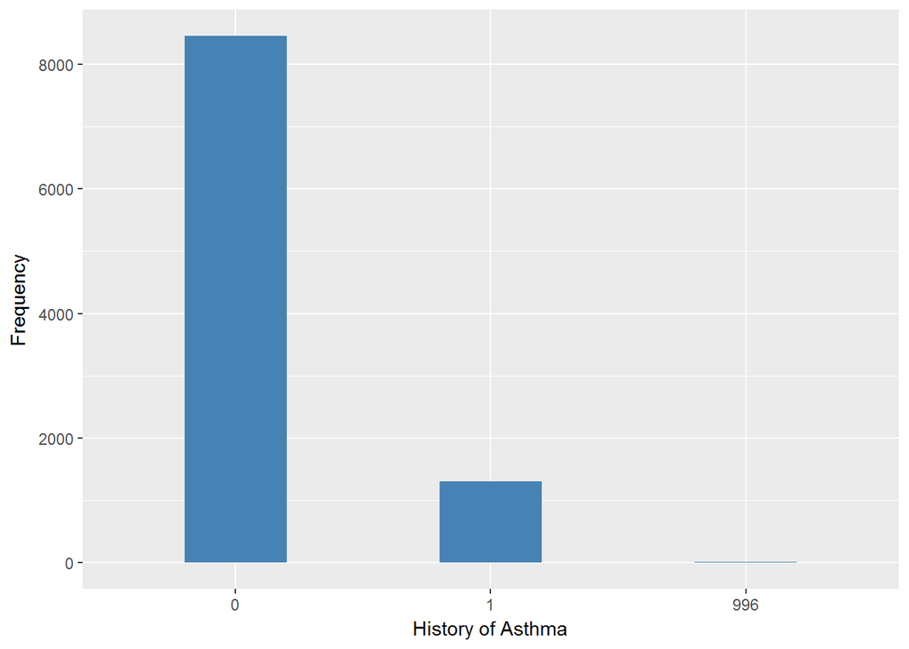

h_cpd

| Sample size | Missing values |
| --- | --- |
| 9771 | 8 |

Category

|  | 0 | 1 |
| --- | --- | --- |
| Frequency | 9105.00 | 658.00 |
| Percentage | 93.18 | 6.73 |

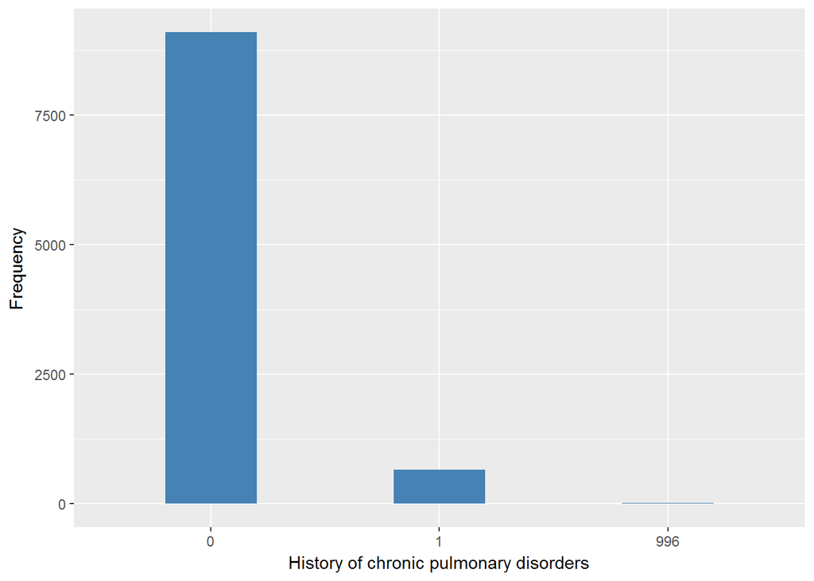

#### 2.1.3.2 Harmonisation algorithm

To compute `h_respiratory` from the study-specific variable it has to be recoded as follows:

- `h_asthma == 0 and h_cpd == 0 into 0`
- `h_asthma == 1 or h_cpd == 1 into 1`
- `keep missing values into themselves`

**R script:**

```r
# Categorical variable harmonization
ELSA_ds_w3 <- tibble(id = ELSA_w3$id)

ELSA_ds_w3$h_respiratory <- rep(999, length(ELSA_ds_w3$id))
ELSA_ds_w3$h_respiratory[which(ELSA_w3$h_asthma == 0 & ELSA_w3$h_cpd == 0)] <- 0
ELSA_ds_w3$h_respiratory[which(ELSA_w3$h_asthma == 1 | ELSA_w3$h_cpd == 1)] <- 1
ELSA_ds_w3$h_respiratory[which((ELSA_w3$h_asthma == 996 & ELSA_w3$h_cpd != 1) |
    (ELSA_w3$h_cpd == 996 & ELSA_w3$h_asthma != 1))] <- 996
```

#### 2.1.3.3 Statistics of the new harmonized variable

Chronic respiratory diseases such respiratory, CPD, COPD, bronchitis, emphysema

| Sample size | Missing values |
| --- | --- |
| 9771 | 7 |

Category

|  | 0 | 1 |
| --- | --- | --- |
| Frequency | 8023.00 | 1741.00 |
| Percentage | 82.11 | 17.82 |

Type of missing

|  | 991 | 992 | 993 | 994 | 995 | 996 | 997 | 998 | 999 | NA |
| --- | --- | --- | --- | --- | --- | --- | --- | --- | --- | --- |
| Frequency | 0 | 0 | 0 | 0 | 0 | 7.00 | 0 | 0 | 0 | 0 |
| Percentage | 0 | 0 | 0 | 0 | 0 | 0.07 | 0 | 0 | 0 | 0 |

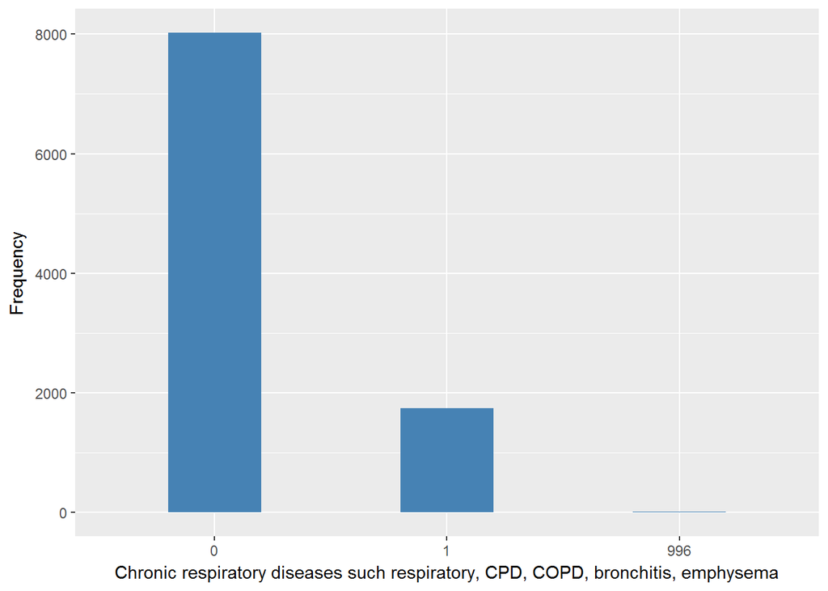

#### 2.1.3.4 Validation

|  | all 0->0 | some 1->1 | 996->996 |
| --- | --- | --- | --- |
| BeforeH | 8023 | 1741 | 7 |
| AfterH | 8023 | 1741 | 7 |

### 2.1.4 Wave 4

#### 2.1.4.1 Study-specific variable description

| **Name** | `h_asthma` | `h_cpd` |
| --- | --- | --- |
| **Label** | `History of Asthma` | `History of chronic pulmonary disorders` |
| **Table name** | `h_asthma` | `h_cpd` |
| **Categories** | `1 = Asthma` `0 = No asthma` | `1 = chronic pulmonary disease` `0 = NO chronic pulmonary disease` |
| **Missings** | `997 = Refuse` `998 = Do not know` | `997 = Refuse` `998 = Do not know` |
| **Description** |  |  |

h_asthma

| Sample size | Missing values |
| --- | --- |
| 11050 | 13 |

Category

|  | 0 | 1 |
| --- | --- | --- |
| Frequency | 9550.00 | 1487.00 |
| Percentage | 86.43 | 13.46 |

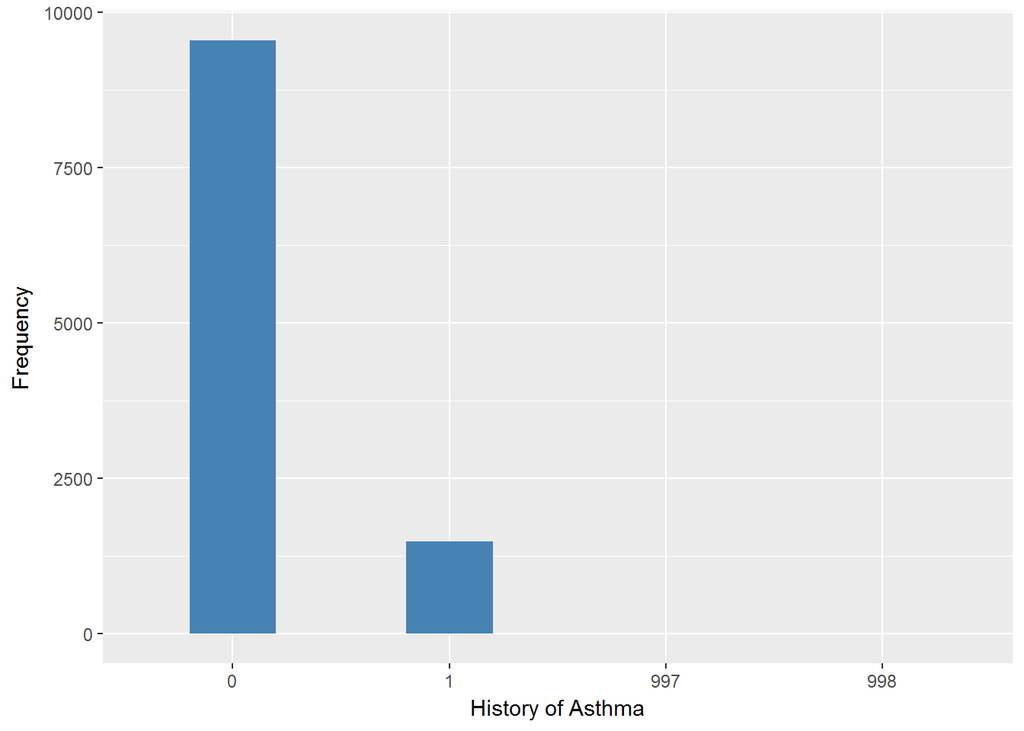

h_cpd

| Sample size | Missing values |
| --- | --- |
| 11050 | 15 |

Category

|  | 0 | 1 |
| --- | --- | --- |
| Frequency | 10309.00 | 726.00 |
| Percentage | 93.29 | 6.57 |

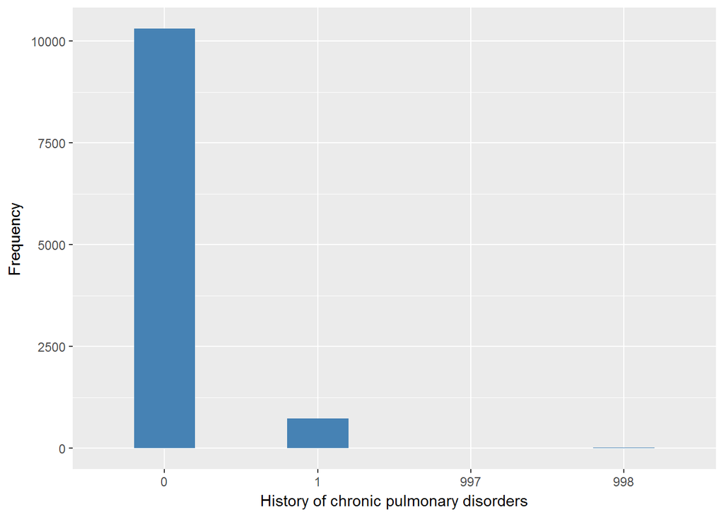

#### 2.1.4.2 Harmonisation algorithm

To compute `h_respiratory` from the study-specific variable it has to be recoded as follows:

- `h_asthma == 0 and h_cpd == 0 into 0`
- `h_asthma == 1 or h_cpd == 1 into 1`
- `keep missing values into themselves`

**R script:**

```r
# Categorical variable harmonization
ELSA_ds_w4 <- tibble(id = ELSA_w4$id)

ELSA_ds_w4$h_respiratory <- rep(999, length(ELSA_ds_w4$id))
ELSA_ds_w4$h_respiratory[which(ELSA_w4$h_asthma == 0 & ELSA_w4$h_cpd == 0)] <- 0
ELSA_ds_w4$h_respiratory[which(ELSA_w4$h_asthma == 1 | ELSA_w4$h_cpd == 1)] <- 1
ELSA_ds_w4$h_respiratory[which((ELSA_w4$h_asthma == 997 & ELSA_w4$h_cpd != 1) |
    (ELSA_w4$h_cpd == 997 & ELSA_w4$h_asthma != 1))] <- 997
ELSA_ds_w4$h_respiratory[which((ELSA_w4$h_asthma == 998 & ELSA_w4$h_cpd != 1) |
    (ELSA_w4$h_cpd == 998 & ELSA_w4$h_asthma != 1))] <- 998
```

#### 2.1.4.3 Statistics of the new harmonized variable

Chronic respiratory diseases such respiratory, CPD, COPD, bronchitis, emphysema

| Sample size | Missing values |
| --- | --- |
| 11050 | 13 |

Category

|  | 0 | 1 |
| --- | --- | --- |
| Frequency | 9097.00 | 1940.00 |
| Percentage | 82.33 | 17.56 |

Type of missing

|  | 991 | 992 | 993 | 994 | 995 | 996 | 997 | 998 | 999 | NA |
| --- | --- | --- | --- | --- | --- | --- | --- | --- | --- | --- |
| Frequency | 0 | 0 | 0 | 0 | 0 | 0 | 5.00 | 8.00 | 0 | 0 |
| Percentage | 0 | 0 | 0 | 0 | 0 | 0 | 0.05 | 0.07 | 0 | 0 |

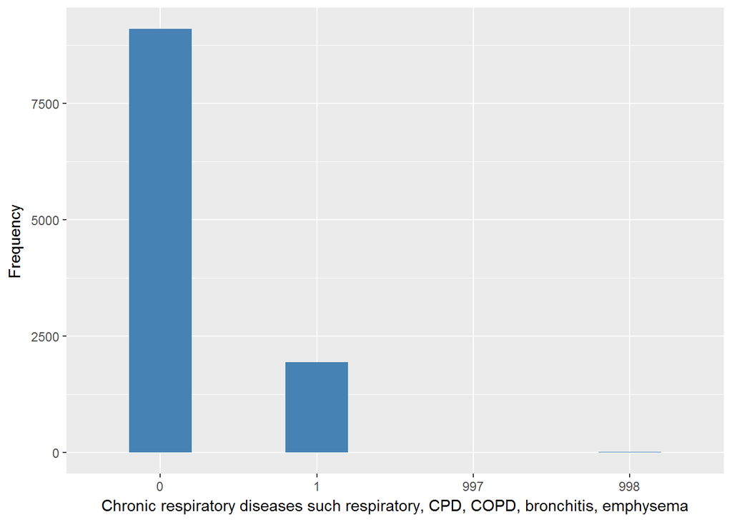

#### 2.1.4.4 Validation

|  | all 0->0 | some 1->1 | 997->997 | 998->998 |
| --- | --- | --- | --- | --- |
| BeforeH | 9097 | 1940 | 5 | 8 |
| AfterH | 9097 | 1940 | 5 | 8 |

### 2.1.5 Wave 5

#### 2.1.5.1 Study-specific variable description

| **Name** | `h_asthma` | `h_cpd` |
| --- | --- | --- |
| **Label** | `History of Asthma` | `History of chronic pulmonary disorders` |
| **Table name** | `h_asthma` | `h_cpd` |
| **Categories** | `1 = Asthma` `0 = No asthma` | `1 = chronic pulmonary disease` `0 = NO chronic pulmonary disease` |
| **Missings** | `997 = Refuse` `998 = Do not know` | `997 = Refuse` `998 = Do not know` |
| **Description** |  |  |

h_asthma

| Sample size | Missing values |
| --- | --- |
| 10274 | 15 |

Category

|  | 0 | 1 |
| --- | --- | --- |
| Frequency | 8801.00 | 1458.00 |
| Percentage | 85.66 | 14.19 |

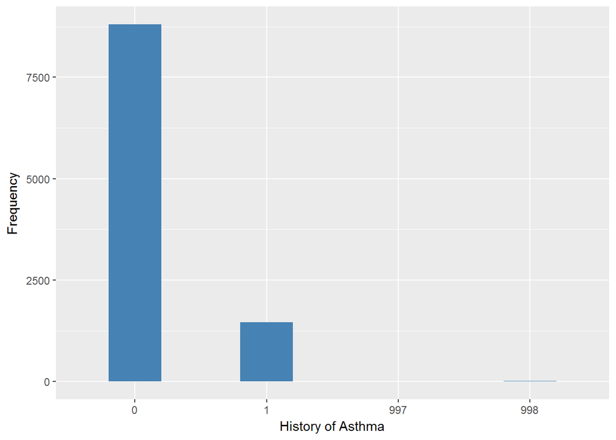

h_cpd

| Sample size | Missing values |
| --- | --- |
| 10274 | 14 |

Category

|  | 0 | 1 |
| --- | --- | --- |
| Frequency | 9516.00 | 744.00 |
| Percentage | 92.62 | 7.24 |

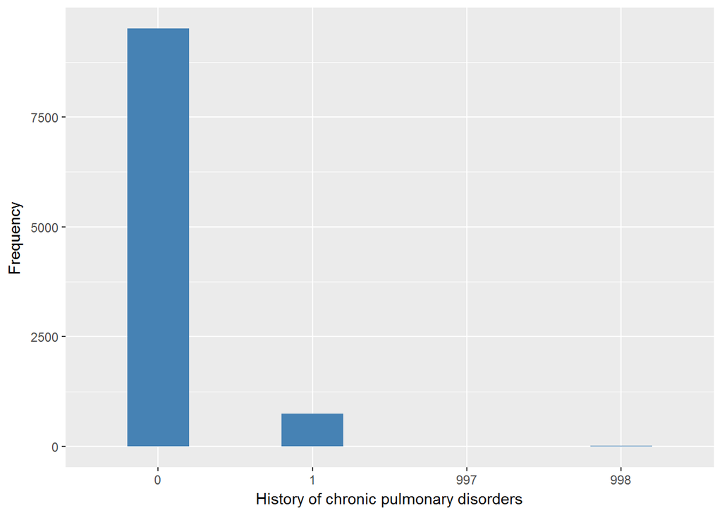

#### 2.1.5.2 Harmonisation algorithm

To compute `h_respiratory` from the study-specific variable it has to be recoded as follows:

- `h_asthma == 0 and h_cpd == 0 into 0`
- `h_asthma == 1 or h_cpd == 1 into 1`
- `keep missing values into themselves`

**R script:**

```r
# Categorical variable harmonization
ELSA_ds_w5 <- tibble(id = ELSA_w5$id)

ELSA_ds_w5$h_respiratory <- rep(999, length(ELSA_ds_w5$id))
ELSA_ds_w5$h_respiratory[which(ELSA_w5$h_asthma == 0 & ELSA_w5$h_cpd == 0)] <- 0
ELSA_ds_w5$h_respiratory[which(ELSA_w5$h_asthma == 1 | ELSA_w5$h_cpd == 1)] <- 1
ELSA_ds_w5$h_respiratory[which((ELSA_w5$h_asthma == 997 & ELSA_w5$h_cpd != 1) |
    (ELSA_w5$h_cpd == 997 & ELSA_w5$h_asthma != 1))] <- 997
ELSA_ds_w5$h_respiratory[which((ELSA_w5$h_asthma == 998 & ELSA_w5$h_cpd != 1) |
    (ELSA_w5$h_cpd == 998 & ELSA_w5$h_asthma != 1))] <- 998
```

#### 2.1.5.3 Statistics of the new harmonized variable

Chronic respiratory diseases such respiratory, CPD, COPD, bronchitis, emphysema

| Sample size | Missing values |
| --- | --- |
| 10274 | 14 |

Category

|  | 0 | 1 |
| --- | --- | --- |
| Frequency | 8358.00 | 1902.00 |
| Percentage | 81.35 | 18.51 |

Type of missing

|  | 991 | 992 | 993 | 994 | 995 | 996 | 997 | 998 | 999 | NA |
| --- | --- | --- | --- | --- | --- | --- | --- | --- | --- | --- |
| Frequency | 0 | 0 | 0 | 0 | 0 | 0 | 4.00 | 10.0 | 0 | 0 |
| Percentage | 0 | 0 | 0 | 0 | 0 | 0 | 0.04 | 0.1 | 0 | 0 |

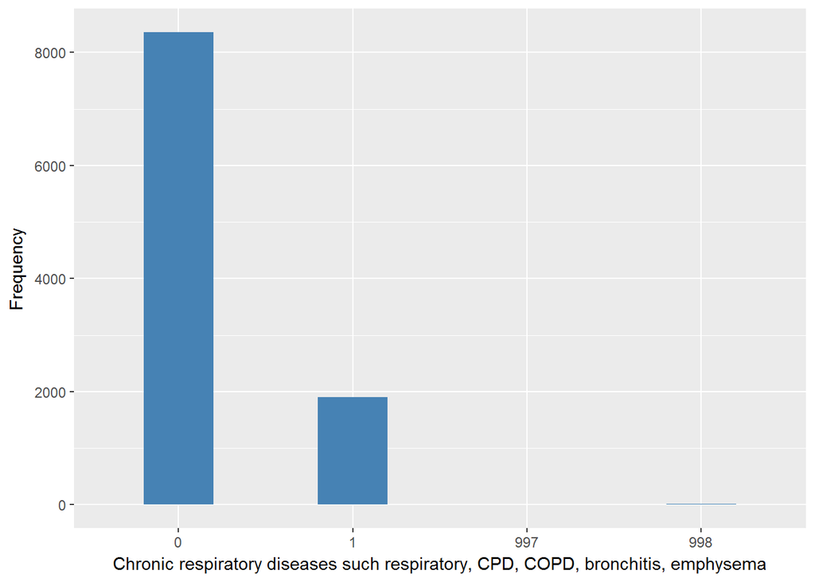

#### 2.1.5.4 Validation

|  | all 0->0 | some 1->1 | 997->997 | 998->998 |
| --- | --- | --- | --- | --- |
| BeforeH | 8358 | 1902 | 4 | 10 |
| AfterH | 8358 | 1902 | 4 | 10 |

### 2.1.6 Wave 6

#### 2.1.6.1 Study-specific variable description

| **Name** | `h_asthma` | `h_cpd` |
| --- | --- | --- |
| **Label** | `History of Asthma` | `History of chronic pulmonary disorders` |
| **Table name** | `h_asthma` | `h_cpd` |
| **Categories** | `1 = Asthma` `0 = No asthma` | `1 = chronic pulmonary disease` `0 = NO chronic pulmonary disease` |
| **Missings** | `997 = Refuse` `998 = Do not know` | `997 = Refuse` `998 = Do not know` |
| **Description** |  |  |

h_asthma

| Sample size | Missing values |
| --- | --- |
| 10601 | 8 |

Category

|  | 0 | 1 |
| --- | --- | --- |
| Frequency | 9078.00 | 1515.00 |
| Percentage | 85.63 | 14.29 |

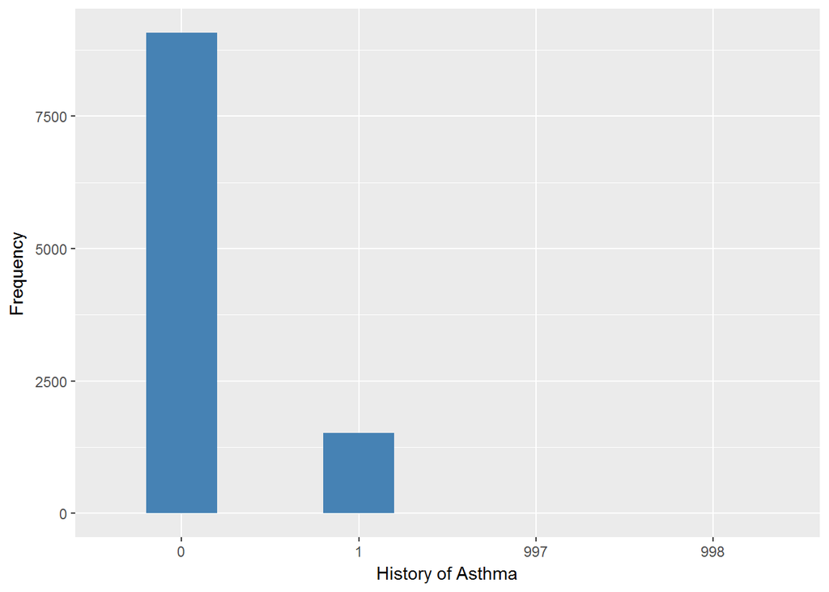

h_cpd

| Sample size | Missing values |
| --- | --- |
| 10601 | 8 |

Category

|  | 0 | 1 |
| --- | --- | --- |
| Frequency | 9813.00 | 780.00 |
| Percentage | 92.57 | 7.36 |

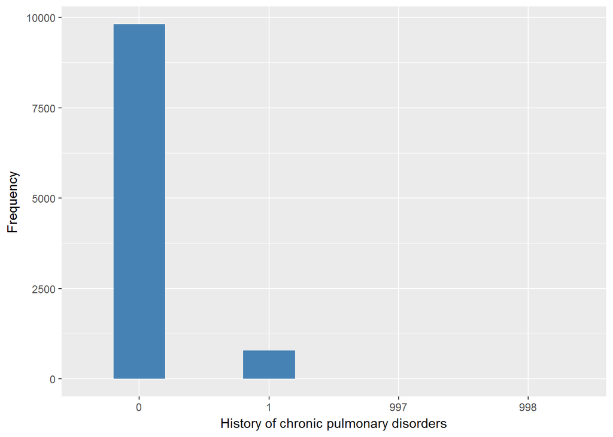

#### 2.1.6.2 Harmonisation algorithm

To compute `h_respiratory` from the study-specific variable it has to be recoded as follows:

- `h_asthma == 0 and h_cpd == 0 into 0`
- `h_asthma == 1 or h_cpd == 1 into 1`
- `keep missing values into themselves`

**R script:**

```r
# Categorical variable harmonization
ELSA_ds_w6 <- tibble(id = ELSA_w6$id)

ELSA_ds_w6$h_respiratory <- rep(999, length(ELSA_ds_w6$id))
ELSA_ds_w6$h_respiratory[which(ELSA_w6$h_asthma == 0 & ELSA_w6$h_cpd == 0)] <- 0
ELSA_ds_w6$h_respiratory[which(ELSA_w6$h_asthma == 1 | ELSA_w6$h_cpd == 1)] <- 1
ELSA_ds_w6$h_respiratory[which((ELSA_w6$h_asthma == 997 & ELSA_w6$h_cpd != 1) |
    (ELSA_w6$h_cpd == 997 & ELSA_w6$h_asthma != 1))] <- 997
ELSA_ds_w6$h_respiratory[which((ELSA_w6$h_asthma == 998 & ELSA_w6$h_cpd != 1) |
    (ELSA_w6$h_cpd == 998 & ELSA_w6$h_asthma != 1))] <- 998
```

#### 2.1.6.3 Statistics of the new harmonized variable

Chronic respiratory diseases such respiratory, CPD, COPD, bronchitis, emphysema

| Sample size | Missing values |
| --- | --- |
| 10601 | 8 |

Category

|  | 0 | 1 |
| --- | --- | --- |
| Frequency | 8616.00 | 1977.00 |
| Percentage | 81.28 | 18.65 |

Type of missing

|  | 991 | 992 | 993 | 994 | 995 | 996 | 997 | 998 | 999 | NA |
| --- | --- | --- | --- | --- | --- | --- | --- | --- | --- | --- |
| Frequency | 0 | 0 | 0 | 0 | 0 | 0 | 4.00 | 4.00 | 0 | 0 |
| Percentage | 0 | 0 | 0 | 0 | 0 | 0 | 0.04 | 0.04 | 0 | 0 |

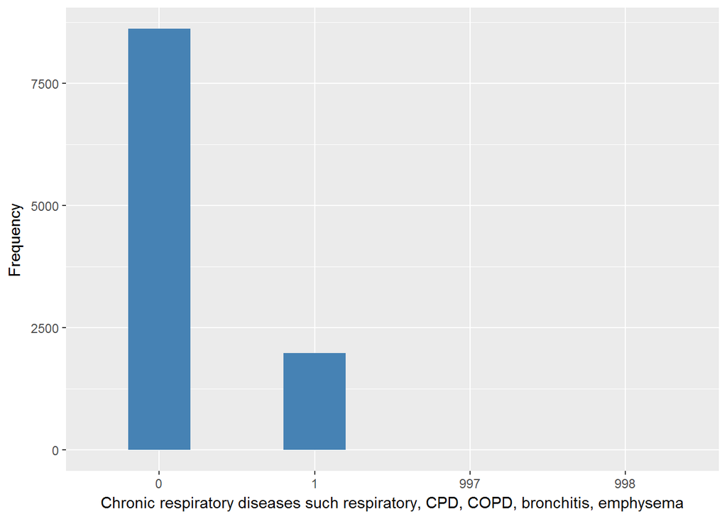

#### 2.1.6.4 Validation

|  | all 0->0 | some 1->1 | 997->997 | 998->998 |
| --- | --- | --- | --- | --- |
| BeforeH | 8616 | 1977 | 4 | 4 |
| AfterH | 8616 | 1977 | 4 | 4 |

### 2.1.7 Wave 7

#### 2.1.7.1 Study-specific variable description

| **Name** | `h_asthma` | `h_cpd` |
| --- | --- | --- |
| **Label** | `History of Asthma` | `History of chronic pulmonary disorders` |
| **Table name** | `h_asthma` | `h_cpd` |
| **Categories** | `1 = Asthma` `0 = No asthma` | `1 = chronic pulmonary disease` `0 = NO chronic pulmonary disease` |
| **Missings** | `998 = Do not know` | `998 = Do not know` |
| **Description** |  |  |

h_asthma

| Sample size | Missing values |
| --- | --- |
| 9666 | 3 |

Category

|  | 0 | 1 |
| --- | --- | --- |
| Frequency | 8233.00 | 1430.00 |
| Percentage | 85.17 | 14.79 |

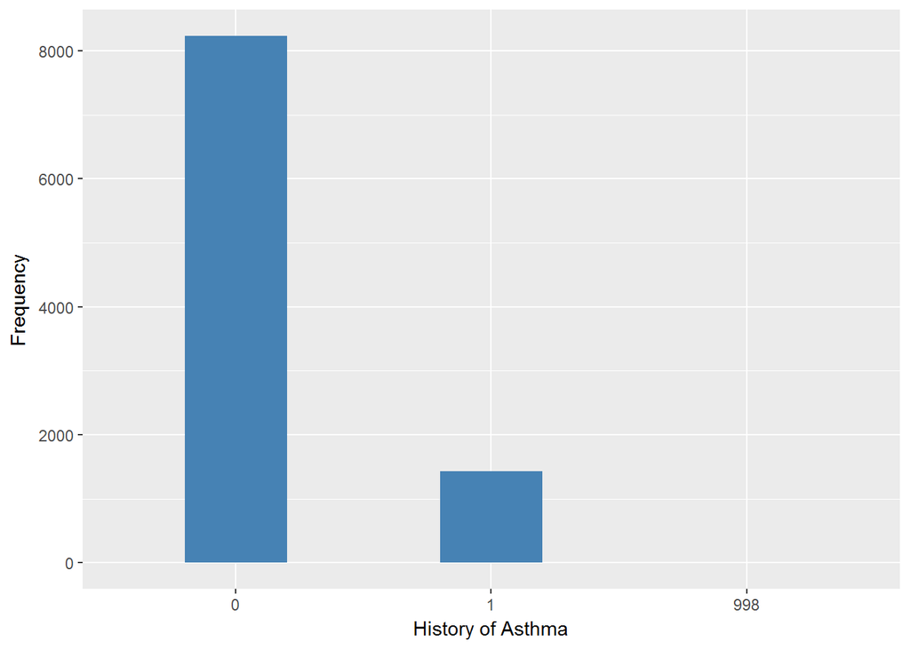

h_cpd

| Sample size | Missing values |
| --- | --- |
| 9666 | 4 |

Category

|  | 0 | 1 |
| --- | --- | --- |
| Frequency | 8919.00 | 743.00 |
| Percentage | 92.27 | 7.69 |

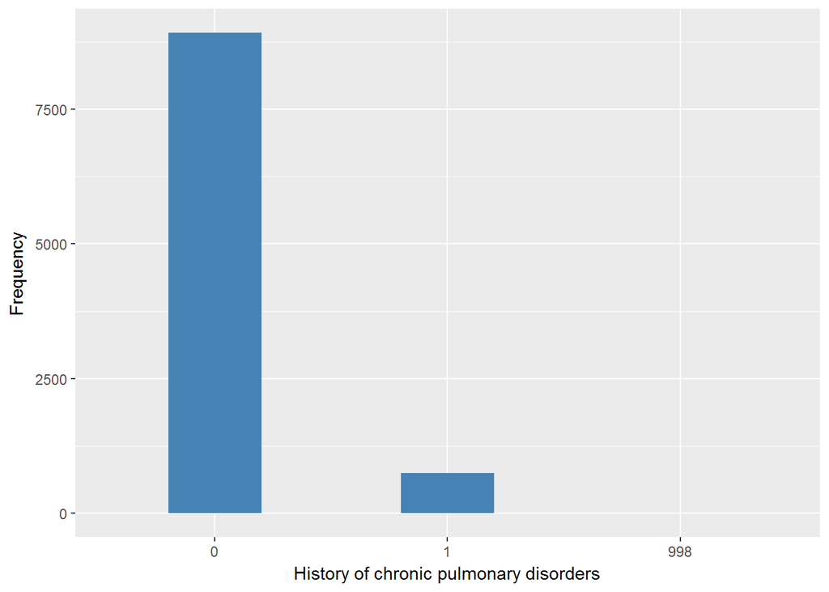

#### 2.1.7.2 Harmonisation algorithm

To compute `h_respiratory` from the study-specific variable it has to be recoded as follows:

- `h_asthma == 0 and h_cpd == 0 into 0`
- `h_asthma == 1 or h_cpd == 1 into 1`
- `keep missing values into themselves`

**R script:**

```r
# Categorical variable harmonization
ELSA_ds_w7 <- tibble(id = ELSA_w7$id)

ELSA_ds_w7$h_respiratory <- rep(999, length(ELSA_ds_w7$id))
ELSA_ds_w7$h_respiratory[which(ELSA_w7$h_asthma == 0 & ELSA_w7$h_cpd == 0)] <- 0
ELSA_ds_w7$h_respiratory[which(ELSA_w7$h_asthma == 1 | ELSA_w7$h_cpd == 1)] <- 1
ELSA_ds_w7$h_respiratory[which((ELSA_w7$h_asthma == 998 & ELSA_w7$h_cpd != 1) |
    (ELSA_w7$h_cpd == 998 & ELSA_w7$h_asthma != 1))] <- 998
```

#### 2.1.7.3 Statistics of the new harmonized variable

Chronic respiratory diseases such respiratory, CPD, COPD, bronchitis, emphysema

| Sample size | Missing values |
| --- | --- |
| 9666 | 3 |

Category

|  | 0 | 1 |
| --- | --- | --- |
| Frequency | 7782.00 | 1881.00 |
| Percentage | 80.51 | 19.46 |

Type of missing

|  | 991 | 992 | 993 | 994 | 995 | 996 | 997 | 998 | 999 | NA |
| --- | --- | --- | --- | --- | --- | --- | --- | --- | --- | --- |
| Frequency | 0 | 0 | 0 | 0 | 0 | 0 | 0 | 3.00 | 0 | 0 |
| Percentage | 0 | 0 | 0 | 0 | 0 | 0 | 0 | 0.03 | 0 | 0 |

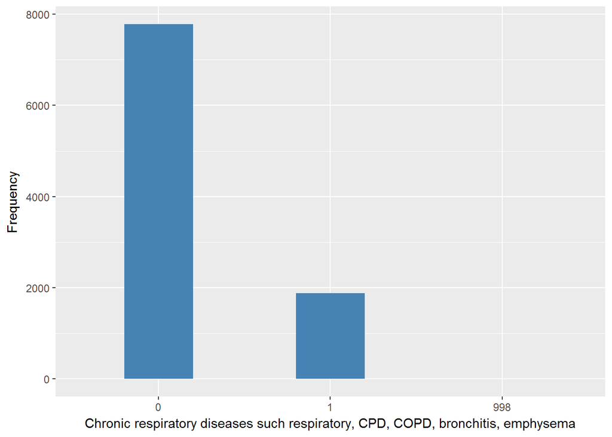

#### 2.1.7.4 Validation

|  | all 0->0 | some 1->1 | 998->998 |
| --- | --- | --- | --- |
| BeforeH | 7782 | 1881 | 3 |
| AfterH | 7782 | 1881 | 3 |

## 2.2 Summary of descriptive statistics of the harmonised variable accross populations and waves

Two tables are generated:

1. Percentages of categories in each harmonised variable.
2. Frequencies and percentages of individuals with different trajectories. To avoid too large table, Only trajectories with percentages larger than 0.3 are shown.

**R script:**

```r
l.hds <- list(w1 = ELSA_ds_w1, w2 = ELSA_ds_w2, w3 = ELSA_ds_w3, w4 = ELSA_ds_w4,
    w5 = ELSA_ds_w5, w6 = ELSA_ds_w6, w7 = ELSA_ds_w7)

for (name in names(l.hds)) {
    aux_object <- l.hds[[name]]
    label(l.hds[[name]][[2]]) <- label(aux_object[[2]]) <- ds_label  # Text value assigned at the DS description, at the top
    l.hds[[name]][[2]] <- labelled(l.hds[[name]][[2]], labels = cat_label)
    aux_object[[2]] <- car::recode(aux_object[[2]], "miss_values_vector=NA")
    aux_object[[2]] <- labelled(aux_object[[2]], labels = cat_label[1:2])
    m_name <- paste0("ELSA_m_ds_", name)
    assign(m_name, aux_object)
    rm(aux_object)
}

t.hds <- frq(l.hds[[1]][2])[[1]][, c(1, 2)]
for (i in seq_along(l.hds)) {
    t.hds[2 + i] <- frq(l.hds[[i]][2])[[1]][, 4]
}
t.hds[13, ] <- c("n", "sample size", length(l.hds[[1]][[2]]), length(l.hds[[2]][[2]]),
    length(l.hds[[3]][[2]]), length(l.hds[[4]][[2]]), length(l.hds[[5]][[2]]),
    length(l.hds[[6]][[2]]), length(l.hds[[7]][[2]]))
names(t.hds) <- c("val", "label", "w1", "w2", "w3", "w4", "w5", "w6", "w7")
kable(t.hds)
```

| val | label | w1 | w2 | w3 | w4 | w5 | w6 | w7 |
| --- | --- | --- | --- | --- | --- | --- | --- | --- |
| 0 | No | 83.92 | 82.32 | 82.11 | 82.33 | 81.35 | 81.28 | 80.51 |
| 1 | Yes | 15.99 | 17.64 | 17.82 | 17.56 | 18.51 | 18.65 | 19.46 |
| 991 | CAPI interviewer error | 0 | 0 | 0 | 0 | 0 | 0 | 0 |
| 992 | Impute | 0 | 0 | 0 | 0 | 0 | 0 | 0 |
| 993 | Disable to measure | 0 | 0 | 0 | 0 | 0 | 0 | 0 |
| 994 | Not attempt not done | 0 | 0 | 0 | 0 | 0 | 0 | 0 |
| 995 | Does not answer | 0 | 0 | 0 | 0 | 0 | 0 | 0 |
| 996 | Not applicable | 0 | 0 | 0.07 | 0 | 0 | 0 | 0 |
| 997 | Refuse | 0.03 | 0.01 | 0 | 0.05 | 0.04 | 0.04 | 0 |
| 998 | Do not know | 0.05 | 0.03 | 0 | 0.07 | 0.1 | 0.04 | 0.03 |
| 999 | Missing | 0 | 0 | 0 | 0 | 0 | 0 | 0 |
| NA | NA | 0 | 0 | 0 | 0 | 0 | 0 | 0 |
| n | sample size | 12099 | 9432 | 9771 | 11050 | 10274 | 10601 | 9666 |

```r
dbb <- merge(ELSA_m_ds_w1[, c("id", "h_respiratory")], ELSA_m_ds_w2[, c("id",
    "h_respiratory")], by = "id", suffixes = c(".w1", ".w2"), all = T)
dbb <- merge(dbb, ELSA_m_ds_w3[, c("id", "h_respiratory")], by = "id", all = T)
dbb <- merge(dbb, ELSA_m_ds_w4[, c("id", "h_respiratory")], by = "id", suffixes = c(".w3",
    ".w4"), all = T)
dbb <- merge(dbb, ELSA_m_ds_w5[, c("id", "h_respiratory")], by = "id", all = T)
dbb <- merge(dbb, ELSA_m_ds_w6[, c("id", "h_respiratory")], by = "id", suffixes = c(".w5",
    ".w6"), all = T)
dbb <- merge(dbb, ELSA_m_ds_w7[, c("id", "h_respiratory")], by = "id", all = T)
names(dbb) <- c("id", "w1", "w2", "w3", "w4", "w5", "w6", "w7")
v.dbb <- paste(dbb[, 2], dbb[, 3], dbb[, 4], dbb[, 5], dbb[, 6], dbb[, 7], dbb[,
    8], sep = "")
f.dbb <- frq(v.dbb)[[1]][, c(1, 2, 4)]
kable(f.dbb[f.dbb[, 3] >= 0.3, ])
```

|  | val | frq | raw.prc |
| --- | --- | --- | --- |
| 1 | 0000000 | 3418 | 18.49 |
| 3 | 000000NA | 513 | 2.77 |
| 8 | 00000NANA | 372 | 2.01 |
| 9 | 0000111 | 55 | 0.30 |
| 18 | 0000NANANA | 476 | 2.57 |
| 26 | 000NA000 | 85 | 0.46 |
| 42 | 000NANANANA | 732 | 3.96 |
| 55 | 00NA0000 | 92 | 0.50 |
| 77 | 00NANANANANA | 1034 | 5.59 |
| 78 | 0111111 | 76 | 0.41 |
| 98 | 0NA00000 | 82 | 0.44 |
| 116 | 0NA0NANANANA | 92 | 0.50 |
| 123 | 0NANA0000 | 59 | 0.32 |
| 154 | 0NANANANANANA | 1697 | 9.18 |
| 155 | 1111111 | 631 | 3.41 |
| 156 | 111111NA | 104 | 0.56 |
| 158 | 11111NANA | 93 | 0.50 |
| 162 | 1111NANANA | 94 | 0.51 |
| 169 | 111NANANANA | 166 | 0.90 |
| 182 | 11NANANANANA | 218 | 1.18 |
| 205 | 1NANANANANANA | 384 | 2.08 |
| 235 | NANA00000 | 713 | 3.86 |
| 237 | NANA0000NA | 92 | 0.50 |
| 241 | NANA000NANA | 72 | 0.39 |
| 252 | NANA00NANANA | 101 | 0.55 |
| 268 | NANA0NANANANA | 260 | 1.41 |
| 269 | NANA11111 | 112 | 0.61 |
| 282 | NANANA0000 | 1407 | 7.61 |
| 284 | NANANA000NA | 220 | 1.19 |
| 289 | NANANA00NANA | 144 | 0.78 |
| 299 | NANANA0NANANA | 302 | 1.63 |
| 300 | NANANA1111 | 222 | 1.20 |
| 307 | NANANA1NANANA | 61 | 0.33 |
| 308 | NANANANA000 | 75 | 0.41 |
| 317 | NANANANANA00 | 806 | 4.36 |
| 319 | NANANANANA0NA | 229 | 1.24 |
| 320 | NANANANANA11 | 130 | 0.70 |
| 322 | NANANANANANA0 | 431 | 2.33 |
| 323 | NANANANANANA1 | 79 | 0.43 |

# 3 Quality estimation

The harmonizated variable contains information about asthma and chronic lung disease, such as chronic bronchitis and emphysema. It has been built from the harmonized single disease variables.